# M4: ctmm-Based Movement Metrics: Speed and Distance

Day 2 — Movement Metrics

Animal Movement Analyses for Ecologists | SYSU Shenzhen, July 2026

2026-07-27

*Created: 2026-06-30* | *Last updated: 2026-07-27*

## 1 Learning Objectives

By the end of this module you will be able to:

1. Estimate the mean speed of an animal from its tracking data.
2. Perform a meta-analysis to estimate the mean speed of a population.
3. Calculate instantaneous speeds and derive distances from speed estimates.

**Packages used:** `ctmm`

## 2 Background

Estimating the movement speed of an individual animal and its distance traveled can provide insights into its behavior and activity (energetics). Ideally, we would need very fine sampling to get good, realistic estimates of distance traveled based on an individual’s tracked movement path, from which we can calculate its speed. Of course, this is not always feasible and there are often many logistical constraints for using a short sampling interval, as well as [trade-offs with sampling duration](https://doi.org/10.1002/ece3.73755).

Conventional straight-line distance (SLD) can be easily calculated as $\sqrt{(\Delta x^2+\Delta y^2)}$, but this is heavily biased. In many cases, SLD will underestimate the true distance traveled, unless an animal moves in a perfectly straight line. And, in cases where the animal does not move much relative to the GPS location error (*more to come*) of its tracking device, SLD can greatly overestimate the distance traveled. This also impacts our speed estimates. Here, we will use the [continuous-time speed and distance (CTSD)](https://doi.org/10.1186/s40462-019-0177-1) estimator to get more accurate mean speed, instantaneous speeds, and distance estimates based on the CTMM framework.

## 3 Data preparation

Like in the previous module, let’s first import our data, center the projection so that North points up, and then visualize our data. We will use the GPS-collared African buffalo (*Syncerus caffer*) data set again, but we will focus just on the first individual, Cilla.

### 3.1 Import and Visualize Data

```
## DOP values missing. Assuming DOP=1.
```

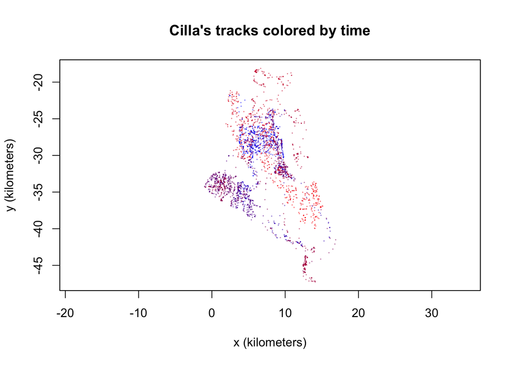

```r
# Load ctmm package
library(ctmm)

# Load buffalo dataset from ctmm
data(buffalo)

# Projection with North = up
projection(buffalo) <- median(buffalo)  # center on geometric median of locations

# Let's consider just first buffalo (Cilla)
DATA <- buffalo[[1]]

# Plot Cilla's tracks
plot(DATA, col = color(DATA, by = "time"),  # color by time
     main = "Cilla's tracks colored by time")
```

### 3.2 Model Selection

Remember that model selection (`ctmm.select`) is often the slowest step of the analysis, but also absolutely integral to any continuous-time analysis, so it is good practice to store the results and save it as an R data file (.rda) that can be easily (and quickly) reloaded whenever it is needed.

```r
# Model selection
## Guesstimate autocorrelation parameters
GUESS <- ctmm.guess(data = DATA, interactive = FALSE)
FIT <- ctmm.select(data = DATA, CTMM = GUESS)  # fit and select movement models
# save(FIT, file = "Data/Cilla.rda")  # save results
```

```r
# Load model fits from ctmm.select
load("Data/cilla.rda")

# Remember our handy units operator?
# help(`%#%`)  # conversion to SI units

1 %#% 'day'  # 1 day in seconds
```

```
## [1] 86400
```

```r
1 %#% 'year'  # 1 year in seconds
```

```
## [1] 31556924
```

For the sake of time, we will demonstrate speed estimation on only the first week of data. This is where handy `%#%` unit conversion operator can be especially helpful. We will use it to subset our data to the first week, by having it calculate the number of seconds in 1 week and keeping everything in our data that is equal or less than that. Then, we will re-fit our movement models to that data subset, in case Cilla behaved differently in that first week compared to her overall movement. We can just use the models we already fit (`FIT`) as a starting point for this.

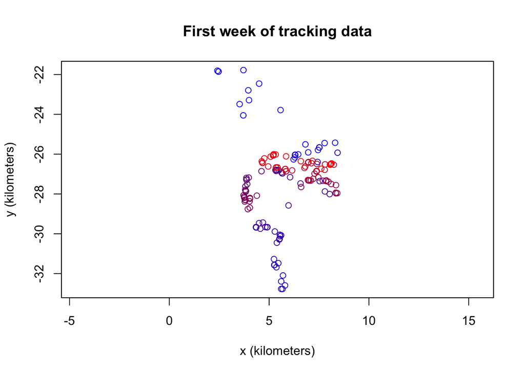

```r
# For the sake of time, we will demonstrate only on the first week of data
DATA <- DATA[DATA$t <= DATA$t[1] + 1 %#% 'week',]  # subset to first week

# Plot without errors (easier to see the location points)
plot(DATA, col = color(DATA, by = 'time'),  # color by time
     error = FALSE, main = "First week of tracking data")
```

```r
## Less data so ctmm.select should fit relatively quicker

# Re-fit to first week only
FIT <- ctmm.select(DATA, FIT, trace = 1)
```

```
## * Fitting model OUF anisotropic
```

```
## * Fitting model OU anisotropic
```

```
## * Fitting model OUf anisotropic
```

```
## * Fitting model OUF
```

```r
summary(FIT)$name  # OUF anisotropic was the best fit model
```

```
## [1] "OUF anisotropic"
```

## 4 Speed and Distance Estimation

### 4.1 RMS Speed and Mean Speed

The summary of parameter estimates output from model selection gives a value for speed from the best fit model. This is the estimate for Gaussian root-mean squared (RMS) speed, which is a proxy for the actual average speed.

$$\text{RMS
Speed}=\hat{v}_{RMS}=\sqrt{E[v^2]}$$

$$\text{Mean
Speed}=\hat{\bar{v}}=E[v]$$

$$\text{Mean Speed (over tracked
period)}=\frac{1}{t_n-t_1}\times\int_{t_1}^{t_n}{v(t)\space
dt}$$

Both speed estimates assume Gaussian (Normal) distributed locations and speeds.

```r
# Gaussian RMS speed from summary statistics
summary(FIT)
```

```
## $name
## [1] "OUF anisotropic"
##
## $DOF
##       mean       area  diffusion      speed
##   7.877899  11.804171  35.378897 127.059645
##
## $CI
##                                          low       est      high
## area (square kilometers)          38.2633016 74.524299 122.66970
## τ[position] (hours)                4.8552534 10.996887  24.90736
## τ[velocity] (hours)                0.8192454  1.175693   1.68723
## speed (kilometers/day)            17.6855956 19.369429  21.05135
## diffusion (square kilometers/day)  9.7969430 14.035460  19.02394
```

```r
## contains Gaussian root-mean squared (RMS) speed -- proxy of speed
## mean speed: v^- = E[v] = 1/(tn-t1)*integral of speed over time
## RMS speed: v_rms = root(E[v^2])
```

Now let’s calculate the Gaussian mean speed (regular mean speed, not RMS speed) from the best fit model. This should be within an order of magnitude of the RMS speed.

```r
# Calculate Gaussian (regular mean speed - not RMS)
speed(FIT, trace = FALSE)  # keep trace = TRUE to see the progress bar
```

```
## $DOF
##    speed
## 132.8231
##
## $CI
##                             low      est     high
## speed (kilometers/day) 15.60685 17.02509 18.50588
##
## attr(,"class")
## [1] "speed"
```

### 4.2 Continuous-time Speed and Distance (CTSD)

It can often be difficult to disentangle the continuous-time movement process that dictates the speed of an animal, from the discrete-time sampling process (only track points every so often). [**Continuous-time speed and distance (CTSD)** estimation](https://doi.org/10.1186/s40462-019-0177-1) provides a non-parametric method for estimating mean speed, which targets the underlying continuous-time movement process of an individual. CTSD uses a simulation-based approach to sample from the distribution of trajectories conditioned on our data. we calculate the mean speeds of the trajectories simulated from our tracking data and the best-fit movement model to obtain a more robust mean speed estimate (averaging the simulated mean speeds).

The function used is the same (`speed`), but here we will add the telemetry data for the simulations to condition, along with the selected movement model. We caution that speed estimation requires a model that includes the **velocity autocorrelation parameter** ($\tau_v$). Additionally, it is best practice to fit an error model (*more to come*) based on device calibration data to the data, as speed estimates can be overestimated if there is little movement relative to the magnitude of location error.

```r
# Non-parametric speed estimation (CTSD: Noonan, et al., 2019)
speed(DATA, CTMM = FIT, trace = FALSE)
```

```
## $DOF
##    speed
## 324.8617
##
## $CI
##                             low      est     high
## speed (kilometers/day) 12.49886 13.21251 13.93581
##
## attr(,"class")
## [1] "speed"
```

```r
## This gives mean of mean speeds (from simulations)
```

> **NOTE:** When handling data for species with very distinct movement behaviours, *speed calculations should be segmented*.
> - For example, speeds should be calculated separately for birds when they are stationary/feeding on ground VS flying around.

> You can also segment day and night depending on the diel activity of your species; if not, for a diurnal species, there will be slight underestimation during day (when they are more active) and slight overestimation at night (when they are less active). Otherwise, CTSD is fairly insensitive to the effect of coarsening data. Other methods would estimate animal to be slower when data is sampled more coarsely (less frequently).

Remember that these estimates are based on stationary movement models (assuming that parameters do not change over time), so you may wish to segment animal tracks if they exhibit different behaviors and run separate models on the partitioned data. See the [appendix](https://link.springer.com/article/10.1186/s40462-019-0177-1#Sec13) of Noonan et al. (2019) for more details.

### 4.3 Sensitivity Analysis Case Study

Ideally, we want our speed estimates to be robust and as accurate to the true average speed of our animal as possible, but this is often limited by our ability to collect high enough resolution data. In this section, we will demonstrate how sampling parameters can impact speed estimates calculated using RMS speed, mean speed, and non-parametric speed estimation (CTSD), by conducting a sensitivity analysis to the sampling interval (i.e., time between consecutive location points).

To reproduce what it would be like to have less data, we will coarsen the data by removing every other timestamp, such that we lose half the data, while still maintaining about the same sampling duration. This would effectively be sampling half as frequently (doubling the sampling interval). We will iterate this process until we can no longer reliably estimate the mean speed. Note that when we have less data, the models fit more quickly, but we cannot calculate a speed estimate if the data becomes too coarse (resolution of the data is not high enough). Let’s see how the mean speed estimates change across the different methods. The original data was 1-hour sampling, so after the first iteration, we will have 2-hour sampling.

```r
# Impact of coarsening the data
SUB <- DATA  # duplicate so we don't lose the original data
FIT.SUB <- FIT

# Remove every other time
## This coarsens the data by removing half of it, while maintaining the duration
SUB <- SUB[as.logical(1:nrow(SUB)%%2),]
FIT.SUB <- ctmm.select(SUB, FIT.SUB, trace = FALSE)  # fits more quickly w/ less data
## the speed estimate here is RMS Gaussian
## won't get speed estimate if too coarse

summary(FIT.SUB)  # wider CIs
```

```
## $name
## [1] "OUF anisotropic"
##
## $DOF
##      mean      area diffusion     speed
##  6.303190  9.069791 30.655538 38.365920
##
## $CI
##                                         low      est      high
## area (square kilometers)          34.354542 74.86027 130.87233
## τ[position] (hours)                5.836160 14.87489  37.91233
## τ[velocity] (minutes)             23.882589 48.71872  99.38260
## speed (kilometers/day)            16.894363 20.06501  23.22996
## diffusion (square kilometers/day)  7.755129 11.44098  15.83214
```

```r
## Gaussian (regular speed - not RMS)
## Note the diffusion rate

# Mean speed
speed(FIT.SUB, trace = FALSE)
```

```
## $DOF
##    speed
## 38.44821
##
## $CI
##                             low      est     high
## speed (kilometers/day) 14.92709 17.61011 20.51785
##
## attr(,"class")
## [1] "speed"
```

```r
## similar estimates to finer sampled data, but more uncertainty (larger CIs)

# non-parametric speed estimation
speed(SUB, FIT.SUB, trace = FALSE)  # fits more slowly w/ less data
```

```
## $DOF
##   speed
## 16.7708
##
## $CI
##                             low      est     high
## speed (kilometers/day) 12.75519 16.62254 20.73068
##
## attr(,"class")
## [1] "speed"
```

```r
## Note lower DOF[speed], effective sample size for speed estimation
## Movement model may switch when data is too coarse
```

Let’s repeat this process again, now 4-hour sampling…

```r
# Remove every other time
## This coarsens the data by removing half of it, while maintaining the duration
SUB <- SUB[as.logical(1:nrow(SUB)%%2),]
FIT.SUB <- ctmm.select(SUB, FIT.SUB, trace = FALSE)  # fits more quickly w/ less data
## the speed estimate here is RMS Gaussian

summary(FIT.SUB)  # wider CIs
```

```
## $name
## [1] "OU"
##
## $DOF
##      mean      area diffusion     speed
##  6.807332 10.144614 17.625285  0.000000
##
## $CI
##                                         low      est      high
## area (square kilometers)          32.582441 67.52407 114.98193
## τ[position] (hours)                5.957240 14.10736  33.40769
## diffusion (square kilometers/day)  7.188794 12.20594  18.52948
```

```r
# Gaussian (regular speed - not RMS)

# Mean speed
speed(FIT.SUB, trace = FALSE)
```

```
## $DOF
## speed
##     0
##
## $CI
##                       low est high
## speed (meters/second)   0 Inf  Inf
##
## attr(,"class")
## [1] "speed"
```

```r
## similar estimates to finer sampled data, but more uncertainty (larger CIs)

# non-parametric speed estimation
speed(SUB, FIT.SUB, trace = FALSE)  # fits more slowly w/ less data
```

```
## $DOF
## speed
##     0
##
## $CI
##                       low est high
## speed (meters/second)   0 Inf  Inf
##
## attr(,"class")
## [1] "speed"
```

```r
## Note lower DOF[speed], effective sample size for speed estimation
## Movement model may switch when data is too coarse
```

Note that the non-parametric method for speed estimation fits more slowly with less data, as there is a lower effective sample size ($N_{\text{speed}}$ or DOF[speed], i.e., less information content in the data) for the simulations to be conditioned on, unless the sampling interval becomes too wide to be able to estimate speed. At some point, when the data becomes too coarse, the best-fit movement model selected by `ctmm.select` may change to one that no longer incorporates a velocity autocorrelation ($\tau_v$) component. In that case, we will no longer be able to obtain a speed estimate. However, we can look instead at the diffusion rate, which is a more reliable metric of animal movement activity. Additionally, we should consider the location error (*more to come*).

Let’s repeat the coarsening process one last time, now 8-hour sampling.

```r
# Remove every other time
## This coarsens the data by removing half of it, while maintaining the duration
SUB <- SUB[as.logical(1:nrow(SUB)%%2),]
FIT.SUB <- ctmm.select(SUB, FIT.SUB, trace = FALSE)  # fits more quickly w/ less data
## the speed estimate here is RMS Gaussian

summary(FIT.SUB)  # wider CIs
```

```
## $name
## [1] "OU"
##
## $DOF
##      mean      area diffusion     speed
##  7.425965 10.639029  9.164541  0.000000
##
## $CI
##                                         low      est      high
## area (square kilometers)          34.011905 69.07801 116.35767
## τ[position] (hours)                4.332488 12.08019  33.68296
## diffusion (square kilometers/day)  6.724359 14.58224  25.42969
```

```r
# Gaussian (regular speed - not RMS)

# Mean speed
speed(FIT.SUB, trace = FALSE)
```

```
## $DOF
## speed
##     0
##
## $CI
##                       low est high
## speed (meters/second)   0 Inf  Inf
##
## attr(,"class")
## [1] "speed"
```

```r
## similar estimates to finer sampled data, but more uncertainty (larger CIs)

# non-parametric speed estimation
speed(SUB, FIT.SUB, trace = FALSE)  # fits more slowly w/ less data
```

```
## $DOF
## speed
##     0
##
## $CI
##                       low est high
## speed (meters/second)   0 Inf  Inf
##
## attr(,"class")
## [1] "speed"
```

```r
## Note lower DOF[speed], effective sample size for speed estimation
## Movement model may switch when data is too coarse
```

Although, we can no longer estimate the animal’s speed, we can still estimate her diffusion rate, which has stayed relatively insensitive to the sampling interval (remains more accurate and precise than speed), and does not require a model with velocity autocorrelation.

## 5 Population Mean Speed

In this section, we will walk though how to conduct a meta-analysis, comparing mean speeds across individuals and calculating the average of mean speeds in the population. We will use the `meta` function for this (see `help(meta)`).

```r
help('meta')  # population meta-analysis for movement parameters
```

First, we would need to go through the same speed estimation process as we did above (Sections 3-4.2), but for all 6 individual buffalo. We have already gone through the data preparation steps and run the model selection (Section 3), so let’s start from loading in the saved model results (`FITS`):

```r
# Load in the fitted movement models for all 6 buffalo
load("Data/buffalo.rda")
```

Now we will use the CTSD method for estimating each buffalo’s mean speed. This can be conveniently done by looping through the process for each individual, using a “for” loop. Since this process may be slow, depending on your data, so save your results!

```r
# Estimate mean speed for each buffalo
SPEEDS <- list()  # empty list to store results
for(i in 1:length(buffalo)) {  # open for loop

  # Estimate mean speed and store in the list
  SPEEDS[[i]] <- speed(buffalo[[i]], FITS[[i]])  # this can be slow
}  # close for loop

names(SPEEDS) <- names(buffalo)  # match names to the buffalo

save(SPEEDS, file = "Data/buffalo_speeds.rda")  # save the results
```

```r
# Since it can be a slower process, let's load the saved file
load("Data/buffalo_speeds.rda")  # mean speed estimates for each buffalo

# Inspect the results for each individual by printing the `speeds` output
SPEEDS
```

```
## $Cilla
## $DOF
##    speed
## 3337.639
##
## $CI
##                            low      est     high
## speed (kilometers/day) 10.9137 11.10163 11.29034
##
## attr(,"class")
## [1] "speed"
##
## $Gabs
## $DOF
##    speed
## 829.6801
##
## $CI
##                             low      est     high
## speed (kilometers/day) 11.03553 11.42254 11.81281
##
## attr(,"class")
## [1] "speed"
##
## $Mvubu
## $DOF
##    speed
## 862.2483
##
## $CI
##                             low      est     high
## speed (kilometers/day) 10.52691 10.88883 11.25374
##
## attr(,"class")
## [1] "speed"
##
## $Pepper
## $DOF
##    speed
## 414.6357
```

[output cut: 16 more lines]

```
##
## attr(,"class")
## [1] "speed"
##
## $Toni
## $DOF
##  speed
## 1524.7
##
## $CI
##                             low      est     high
## speed (kilometers/day) 11.78162 12.08396 12.38818
##
## attr(,"class")
## [1] "speed"
```

```r
# Speed meta-analysis
meta(SPEEDS, sort = TRUE)  # mean = population mean of mean speeds
```

```
##                    ΔAICc
## inverse-Gaussian   0.000
## Dirac-δ          217.615
```

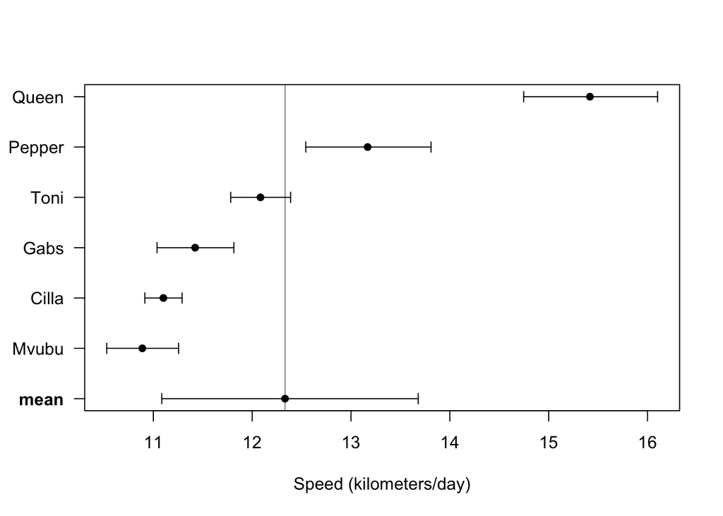

```
##                        low        est        high
## mean (km/day) 11.085053492 12.3325586 13.68011743
## CoV²           0.003242025  0.0168713  0.04151934
## CoV            0.059411833  0.1355311  0.21261309
```

```r
# Diffusion rate meta-analysis
meta(FITS, variable = "diffusion", sort = TRUE)  # mean = population mean diffusion rate
```

```
##                     ΔAICc
## inverse-Gaussian   0.0000
## Dirac-δ          499.0889
```

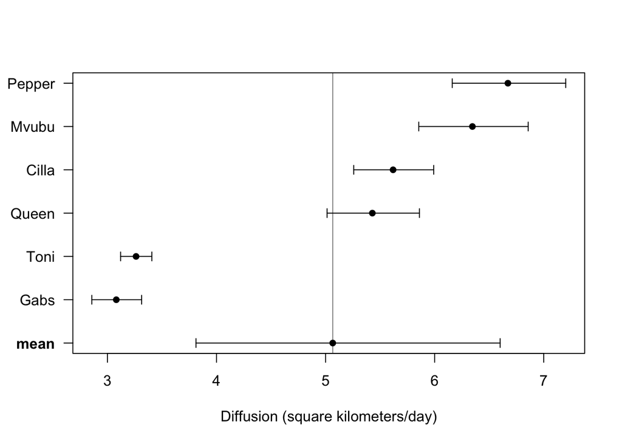

```
##                       low       est      high
## mean (km²/day) 3.81195564 5.0657320 6.6002220
## CoV²           0.02198818 0.1171180 0.2902331
## CoV            0.15485210 0.3573834 0.5625951
```

In the meta-analysis above, the model selection is performed with 2 models: inverse-Gaussian and Dirac-$\delta$, with the inverse-Gaussian being the selected model (lower AICc). The average of mean speeds across buffalo is about 12.3 km/day, highlighted in bold with its 95% CI on the output figure. This figure is a forest plot that compares the mean speed estimates of each individual and 95% CI bars, as well as the meta-analysis mean.

## 6 Instantaneous Speeds

The mean speed provides a summary statistic of an animals activity, however, we are often more interested in calculating the instantaneous speed of an animal at a particular given time. For example, if we are concerned about an animals behavior around roads, we may want to know whether the animal crosses the road quickly or spends time dwelling around the edge before crossing. Instantaneous speeds can also provide an insight on changes in activity level during the course of its movement, either across different areas of its habitat or at different times of day. Instantaneous speeds and CTSD mean speed can also be used to derive the total distance traveled over the course of the study.

Here, we will use the `speeds` function to calculate the CTSD instantaneous speed for our first buffalo (Cilla) at all timestamps, conditioned on our telemetry data and movement model. This includes both the estimated speed, as well as low and high CI bounds. We will then calculate the total distance traveled as:
$$d=\sum_i{\Delta
t_i|v(t_i)|}=\bar{v}\times\sum_j(\Delta t_j)$$
which is the product of the mean speed and total time traveled (sampling duration).

```r
# Speed at a particular given time
INST_SPEEDS <- speeds(buffalo[[1]], FITS[[1]])  # Cilla's instantaneous speeds

head(INST_SPEEDS)  # inspect first 6 times (rows) of the output
```

```
##          low       est      high          t           timestamp
## 1 0.25707722 0.4377979 0.6407323 1121319300 2005-07-14 05:35:00
## 2 0.14231099 0.2806471 0.4406463 1121326500 2005-07-14 07:35:00
## 3 0.15181509 0.2787682 0.4235119 1121330040 2005-07-14 08:34:00
## 4 0.05811116 0.1708467 0.3120615 1121333700 2005-07-14 09:35:00
## 5 0.33044485 0.4620314 0.6039135 1121337300 2005-07-14 10:35:00
## 6 0.24059246 0.3705330 0.5134816 1121340840 2005-07-14 11:34:00
```

```r
# Distance = mean speed x total time
nrow(buffalo$Cilla)  # 3527 total tracked locations
```

```
## [1] 3527
```

```r
mean_speed <- SPEEDS$Cilla$CI / 1 %#% "day"  # convert to km/s
mean_speed * (buffalo$Cilla$t[3527]-buffalo$Cilla$t[1])  # total distance traveled
```

```
##                             low      est     high
## speed (kilometers/day) 1600.987 1628.555 1656.238
```

```r
## Ignore "speed (kilometers/day)" relic from SPEEDS object
```

Cilla traveled about 1628.6 kilometers over the time that she was tracked.

## 7 Key functions reference

| Function | Package | Purpose |
| --- | --- | --- |
| `speed()` | `ctmm` | Estimate the average speed of a tracked animal or use non-parametric estimation conditioned on the data |
| `speeds()` | `ctmm` | Calculate the instantaneous speed of a tracked animal at any given time |
| `meta()` | `ctmm` | Estimate population-level mean parameters from individual movement models and estimates (meta-analysis) |

*Next: **Day 3 — Home Range Estimation** — We will define “home range” and go through different methods used to calculate animal space use, using both discrete-time and continuous-time methods.*